# DATS 6101 Project 2

Syed Ibrahim Hamza, Pratik Shetty, and Dominique Howell

2025-12-14

# 1 Introduction

## 1.1 Project Overview

This project examines the **impact of COVID-19 on obesity and lifestyle behaviors** among U.S. adults using the **CDC Behavioral Risk Factor Surveillance System (BRFSS)** data from **2018–2023**.  
The BRFSS is a nationally representative health survey that collects information on demographics, chronic health conditions, and behavioral risk factors from approximately **400,000 adults annually** across all 50 states, Washington D.C., and U.S. territories.  
Our primary goal is to evaluate how obesity prevalence and lifestyle behaviors such as physical activity and alcohol use have changed before and after the onset of COVID-19, and how these trends vary by demographic and health factors.

## 1.2 Data Sources

- **Raw data**: stored in `Data/Raw/`, obtained from the [CDC BRFSS Annual Data Portal](https://www.cdc.gov/brfss/annual_data/annual_data.htm).
- **Processed data**: cleaned and merged dataset saved in `Data/Processed/`.
- **Final analytical dataset**: `Data/Processed/brfss_2018_2023.rds` (over 100k observations, ~24 variables).

# 2 Question # 1

Obesity is a major public health concern in the United States and is associated with numerous chronic health conditions. Using Behavioral Risk Factor Surveillance System (BRFSS) data from 2020–2023, this study examines whether demographic and lifestyle characteristics can be used to predict adult obesity status.

Research Question:

Can we predict the likelihood of an adult being obese (BMI ≥ 30) based on demographic and lifestyle factors such as age, sex, race/ethnicity, income category, physical activity, and alcohol consumption?

## 2.1 Data Preparation & Variable Selection

Body Mass Index (BMI) was used to define obesity status following CDC guidelines. A binary obesity indicator was created where individuals with a BMI of 30 or higher were classified as obese, and those with a BMI below 30 were classified as non-obese. This outcome variable was represented both as a numeric indicator (0/1) for modeling purposes and as a factor variable to support classification-based methods.

```r
brfss = readRDS('../Data/Processed/brfss_2018_2023.rds')

brfss_postcovid <- subset(brfss, interview_year >= 2020)

brfss_postcovid <- brfss_postcovid %>%
  mutate(
    obese_num = ifelse(bmi >= 30, 1, 0),
    obese = factor(obese_num, labels = c("No", "Yes"))
  )
```

Variables were selected based on prior public health literature and their theoretical relevance to obesity risk. The final analytic dataset includes demographic characteristics, lifestyle behaviors, and temporal indicators that may influence obesity outcomes.

```r
vars <- brfss_postcovid %>%
  dplyr::select(obese, obese_num, bmi, age, sex, race_ethnicity, income_category,
                any_exercise_last_month, binge_drinking,
                max_drinks_30day, interview_year)

glimpse(vars)
```

```
## Rows: 87,662
## Columns: 11
## $ obese                   <fct> No, Yes, No, No, No, No, Yes, No, Yes, No, No,…
## $ obese_num               <dbl> 0, 1, 0, 0, 0, 0, 1, 0, 1, 0, 0, 1, 0, 0, 1, 0…
## $ bmi                     <dbl> 25.09, 30.41, 22.22, 23.63, 29.21, 25.06, 30.4…
## $ age                     <dbl> 67, 45, 57, 35, 49, 37, 56, 68, 65, 56, 73, 69…
## $ sex                     <fct> Male, Male, Female, Male, Male, Female, Female…
## $ race_ethnicity          <fct> White NH, White NH, Black NH, Black NH, White …
## $ income_category         <fct> 25-35k, <15k, >50k, <15k, >50k, <15k, >50k, 25…
## $ any_exercise_last_month <fct> Yes, No, Yes, Yes, Yes, Yes, Yes, Yes, No, Yes…
## $ binge_drinking          <fct> Yes, Yes, No, Yes, No, Yes, No, Yes, No, Yes, …
## $ max_drinks_30day        <dbl> 5, 5, 1, 3, 5, 9, 6, 4, 5, 2, 6, 4, 4, 5, 6, 3…
## $ interview_year          <dbl> 2020, 2020, 2020, 2020, 2020, 2020, 2020, 2020…
```

## 2.2 EDA

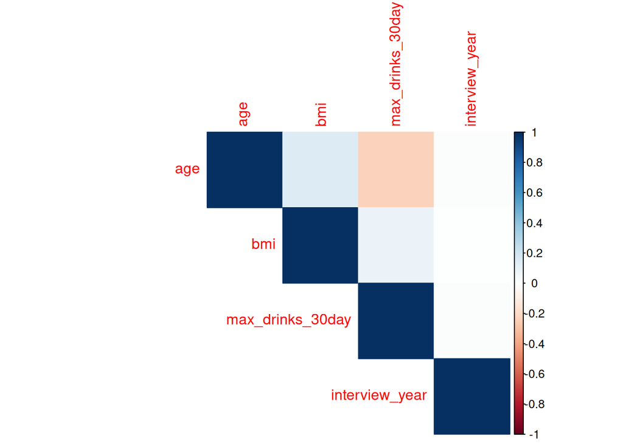

```r
numeric_vars <- vars %>%
  dplyr::select(age, bmi, max_drinks_30day, interview_year)

spearman_corr <- cor(numeric_vars, use = "complete.obs", method = "spearman")

corrplot(spearman_corr, method = "color", type = "upper")
```

The Spearman correlation matrix indicates very weak monotonic relationships among the numerical variables, with the strongest relationships being a weak negative correlation between age and max_drinks_30day (more alcohol consumed in one sitting is associated with younger age) and a weak positive correlation between age and bmi.

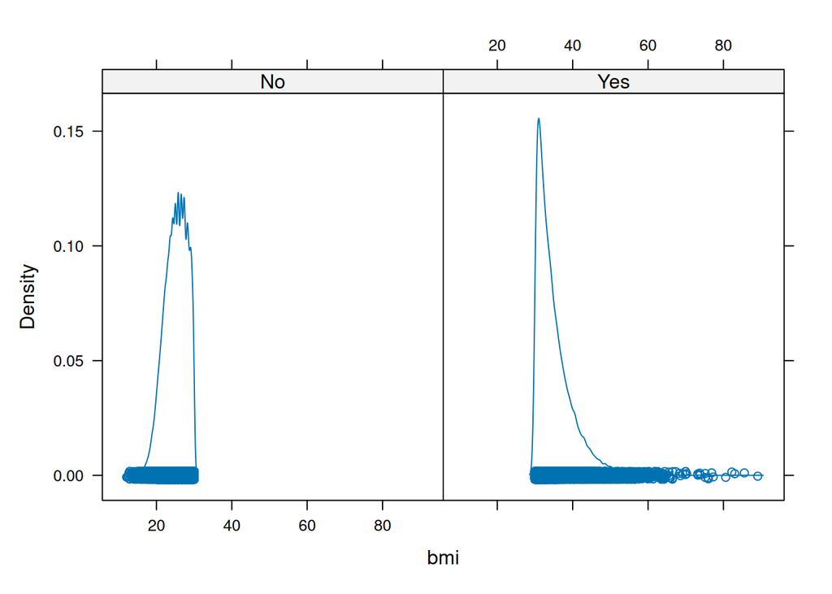

```r
densityplot(~ bmi | obese, data = vars)
```

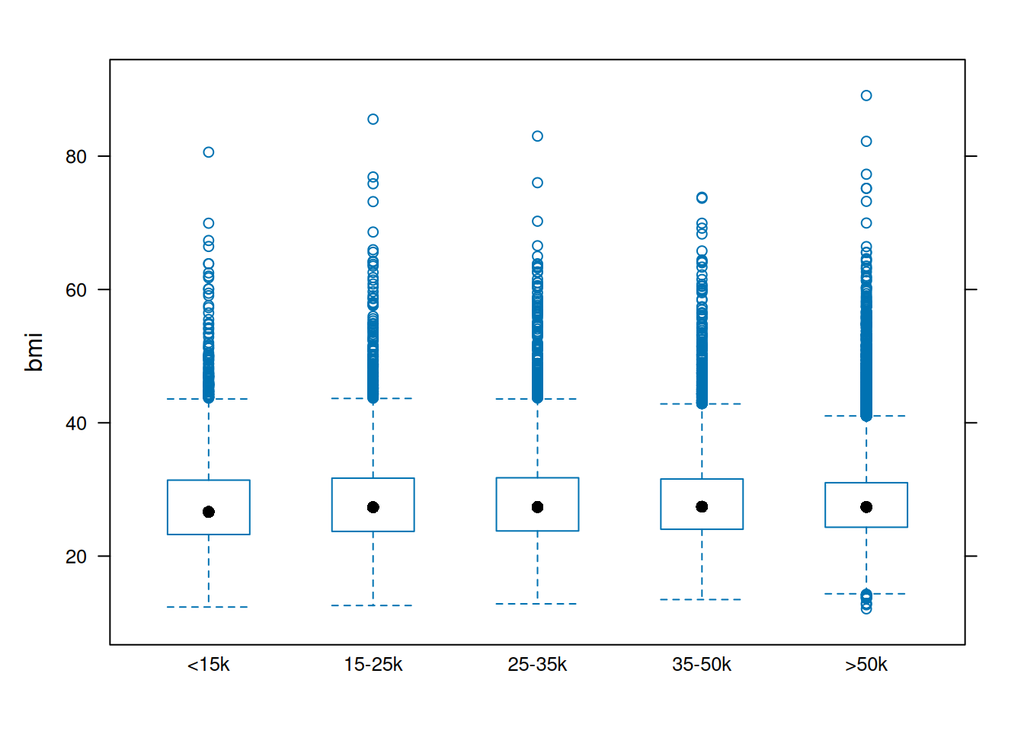

```r
bwplot(bmi ~ income_category, data = vars)
```

This boxplot illustrates the distribution of BMI across Income Categories. The chart shows that the median BMI is nearly constant across all five income brackets, but all categories contain extreme outliers, indicating high-BMI individuals exist across the entire socioeconomic spectrum.

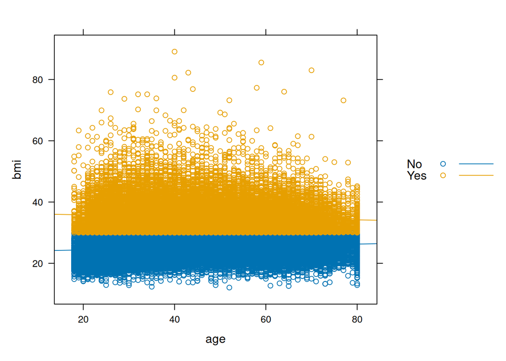

```r
xyplot(bmi ~ age, groups = obese, data = vars,
       auto.key = TRUE, type = c("p", "r"))
```

```r
lm_temp <- lm(bmi ~ age + sex + race_ethnicity + income_category +
                any_exercise_last_month + binge_drinking +
                max_drinks_30day + interview_year,
              data = vars)

xkabledply(vif(lm_temp))
```

Table

|  | GVIF | Df | GVIF^(1/(2*Df)) |
| --- | --- | --- | --- |
| age | 1.0893 | 1 | 1.0437 |
| sex | 1.1156 | 1 | 1.0562 |
| race_ethnicity | 1.1014 | 4 | 1.0121 |
| income_category | 1.1022 | 4 | 1.0122 |
| any_exercise_last_month | 1.0542 | 1 | 1.0267 |
| binge_drinking | 1.0169 | 1 | 1.0084 |
| max_drinks_30day | 1.1726 | 1 | 1.0828 |
| interview_year | 1.0094 | 1 | 1.0047 |

The key finding is that all GVIF (Generalized VIF) values are very close to 1.0 (with the highest being 1.17 for max_drinks_30day). This confirms that there is no significant multicollinearity among your set of predictors, meaning that each variable contributes unique information to the model and their effects can be reliably separated.

## 2.3 Modeling Approach

### 2.3.1 Train–Test Split

```r
set.seed(123)
train_index <- createDataPartition(vars$obese, p = 0.7, list = FALSE)
train <- vars[train_index, ]
test  <- vars[-train_index, ]
```

The dataset was randomly divided into training (70%) and testing (30%) sets using stratified sampling to preserve the distribution of obesity status. The training set was used for model development, while the testing set was reserved for performance evaluation.

### 2.3.2 Feature Engineering

```r
X_train <- model.matrix(obese ~ age + sex + race_ethnicity + income_category +
                          any_exercise_last_month + binge_drinking +
                          max_drinks_30day + interview_year,
                        data = train)[, -1]

X_test <- model.matrix(obese ~ age + sex + race_ethnicity + income_category +
                         any_exercise_last_month + binge_drinking +
                         max_drinks_30day + interview_year,
                       data = test)[, -1]
```

Categorical predictors were converted to numeric format using one-hot encoding to support regression and regularization methods. Feature matrices for the training and testing sets were aligned and cleaned to ensure consistent predictor structures across all models.

### 2.3.3 Baseline Model: Logistic Regression

```r
glm_baseline <- glm(
  obese ~ age + sex + race_ethnicity + income_category +
    any_exercise_last_month + binge_drinking +
    max_drinks_30day + interview_year,
  data = train,
  family = binomial
)

xkabledply(summary(glm_baseline))
```

Table

|  | Estimate | Std. Error | z value | Pr(>&#124;z&#124;) |
| --- | --- | --- | --- | --- |
| (Intercept) | -26.7242 | 16.1649 | -1.6532 | 0.0983 |
| age | 0.0110 | 0.0006 | 18.6780 | 0.0000 |
| sexFemale | -0.0511 | 0.0190 | -2.6888 | 0.0072 |
| race_ethnicityBlack NH | 0.5868 | 0.0385 | 15.2372 | 0.0000 |
| race_ethnicityOther NH | 0.0337 | 0.0433 | 0.7796 | 0.4356 |
| race_ethnicityMultiracial NH | 0.2308 | 0.0537 | 4.2962 | 0.0000 |
| race_ethnicityHispanic | 0.2466 | 0.0294 | 8.3975 | 0.0000 |
| income_category15-25k | 0.1413 | 0.0574 | 2.4607 | 0.0139 |
| income_category25-35k | 0.1724 | 0.0558 | 3.0921 | 0.0020 |
| income_category35-50k | 0.2312 | 0.0535 | 4.3210 | 0.0000 |
| income_category>50k | 0.2119 | 0.0486 | 4.3551 | 0.0000 |
| any_exercise_last_monthNo | 0.5918 | 0.0246 | 24.0939 | 0.0000 |
| binge_drinkingYes | -0.0967 | 0.0185 | -5.2353 | 0.0000 |
| max_drinks_30day | 0.0546 | 0.0035 | 15.4790 | 0.0000 |
| interview_year | 0.0123 | 0.0080 | 1.5357 | 0.1246 |

This logistic regression summary shows that nearly all predictors are statistically significant (many at $p < 0.0001$), with lack of exercise (coefficient 0.5918), Black NH race (coefficient 0.5868), age (coefficient 0.0110), and max drinks (coefficient 0.0546) having the strongest positive association with the log-odds of being obese. The model suggests that the probability of obesity increases with age, max drinks consumed, being in certain minority groups, and not exercising.

### 2.3.4 Best Subset Selection

```r
regfit_bmi <- regsubsets(
  bmi ~ age + sex + race_ethnicity + income_category +
    any_exercise_last_month + binge_drinking +
    max_drinks_30day + interview_year,
  data = train,
  nvmax = 10
)

summary(regfit_bmi)
```

```
## Subset selection object
## Call: regsubsets.formula(bmi ~ age + sex + race_ethnicity + income_category +
##     any_exercise_last_month + binge_drinking + max_drinks_30day +
##     interview_year, data = train, nvmax = 10)
## 14 Variables  (and intercept)
##                              Forced in Forced out
## age                              FALSE      FALSE
## sexFemale                        FALSE      FALSE
## race_ethnicityBlack NH           FALSE      FALSE
## race_ethnicityOther NH           FALSE      FALSE
## race_ethnicityMultiracial NH     FALSE      FALSE
## race_ethnicityHispanic           FALSE      FALSE
## income_category15-25k            FALSE      FALSE
## income_category25-35k            FALSE      FALSE
## income_category35-50k            FALSE      FALSE
## income_category>50k              FALSE      FALSE
## any_exercise_last_monthNo        FALSE      FALSE
## binge_drinkingYes                FALSE      FALSE
## max_drinks_30day                 FALSE      FALSE
## interview_year                   FALSE      FALSE
## 1 subsets of each size up to 10
## Selection Algorithm: exhaustive
##           age sexFemale race_ethnicityBlack NH race_ethnicityOther NH
## 1  ( 1 )  " " " "       " "                    " "
## 2  ( 1 )  "*" " "       " "                    " "
## 3  ( 1 )  "*" " "       " "                    " "
## 4  ( 1 )  "*" " "       "*"                    " "
## 5  ( 1 )  "*" " "       "*"                    " "
## 6  ( 1 )  "*" "*"       "*"                    " "
## 7  ( 1 )  "*" "*"       "*"                    " "
## 8  ( 1 )  "*" "*"       "*"                    " "
## 9  ( 1 )  "*" "*"       "*"                    " "
## 10  ( 1 ) "*" "*"       "*"                    " "
##           race_ethnicityMultiracial NH race_ethnicityHispanic
## 1  ( 1 )  " "                          " "
## 2  ( 1 )  " "                          " "
## 3  ( 1 )  " "                          " "
## 4  ( 1 )  " "                          " "
## 5  ( 1 )  " "                          "*"
## 6  ( 1 )  " "                          "*"
```

[output cut: 22 more lines]

```
## 7  ( 1 )  " "                 "*"                       "*"
## 8  ( 1 )  " "                 "*"                       "*"
## 9  ( 1 )  " "                 "*"                       "*"
## 10  ( 1 ) "*"                 "*"                       "*"
##           max_drinks_30day interview_year
## 1  ( 1 )  " "              " "
## 2  ( 1 )  " "              " "
## 3  ( 1 )  "*"              " "
## 4  ( 1 )  "*"              " "
## 5  ( 1 )  "*"              " "
## 6  ( 1 )  "*"              " "
## 7  ( 1 )  "*"              " "
## 8  ( 1 )  "*"              " "
## 9  ( 1 )  "*"              " "
## 10  ( 1 ) "*"              " "
```

### 2.3.5 LASSO Logistic Regression

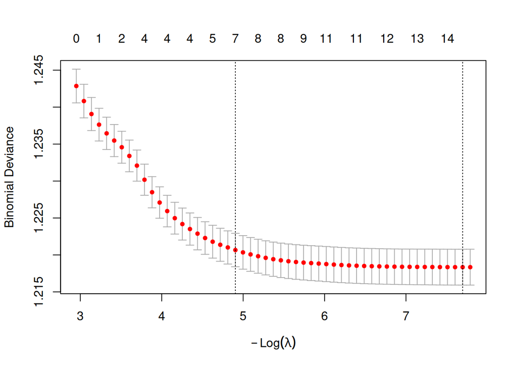

```r
X_train_mat <- as.matrix(X_train)
y_train <- ifelse(train$obese == "Yes", 1, 0)

set.seed(123)
cvfit <- cv.glmnet(X_train_mat, y_train, family = "binomial", alpha = 1)

plot(cvfit)
```

### 2.3.6 Classification Tree

```r
tree_model <- rpart(
  obese ~ age + sex + race_ethnicity + income_category +
    any_exercise_last_month + binge_drinking +
    max_drinks_30day + interview_year,
  data = train,
  method = "class"
)

pred_tree_prob <- predict(tree_model, newdata = test, type = "prob")[, "Yes"]
pred_tree_class <- factor(ifelse(pred_tree_prob > 0.5, "Yes", "No"), levels = c("No","Yes"))
conf_mat_tree <- confusionMatrix(pred_tree_class, test$obese, positive = "Yes")
print(conf_mat_tree)
```

```
## Confusion Matrix and Statistics
##
##           Reference
## Prediction    No   Yes
##        No  18068  8230
##        Yes     0     0
##
##                Accuracy : 0.687
##                  95% CI : (0.6814, 0.6927)
##     No Information Rate : 0.687
##     P-Value [Acc > NIR] : 0.503
##
##                   Kappa : 0
##
##  Mcnemar's Test P-Value : <2e-16
##
##             Sensitivity : 0.000
##             Specificity : 1.000
##          Pos Pred Value :   NaN
##          Neg Pred Value : 0.687
##              Prevalence : 0.313
##          Detection Rate : 0.000
##    Detection Prevalence : 0.000
##       Balanced Accuracy : 0.500
##
##        'Positive' Class : Yes
##
```

```r
roc_tree <- roc(response = test$obese, predictor = pred_tree_prob, levels = c("No","Yes"))
print(auc(roc_tree))
```

```
## Area under the curve: 0.5
```

### 2.3.7 Random Forest

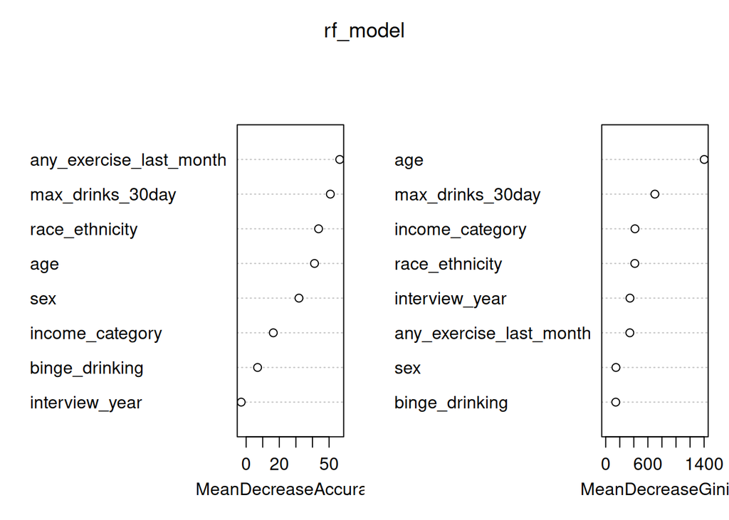

Table

|  | MeanDecreaseAccuracy | MeanDecreaseGini |
| --- | --- | --- |
| age | 41.2191 | 1401.3539 |
| sex | 31.8586 | 146.0663 |
| race_ethnicity | 43.6812 | 413.9502 |
| income_category | 16.3846 | 416.5412 |
| any_exercise_last_month | 56.4230 | 343.5250 |
| binge_drinking | 6.9069 | 143.0563 |
| max_drinks_30day | 50.7769 | 699.7595 |
| interview_year | -2.9710 | 345.2759 |

```r
set.seed(123)
rf_model <- randomForest(
  obese ~ age + sex + race_ethnicity + income_category +
    any_exercise_last_month + binge_drinking +
    max_drinks_30day + interview_year,
  data = train,
  ntree = 500,
  importance = TRUE
)

xkabledply(varImpPlot(rf_model))
```

```r
pred_rf_prob <- predict(rf_model, newdata = test, type = "prob")[, "Yes"]
pred_rf_class <- predict(rf_model, newdata = test, type = "response")
conf_mat_rf <- confusionMatrix(pred_rf_class, test$obese, positive = "Yes")
print(conf_mat_rf)
```

```
## Confusion Matrix and Statistics
##
##           Reference
## Prediction    No   Yes
##        No  17670  7812
##        Yes   398   418
##
##                Accuracy : 0.6878
##                  95% CI : (0.6822, 0.6934)
##     No Information Rate : 0.687
##     P-Value [Acc > NIR] : 0.398
##
##                   Kappa : 0.0381
##
##  Mcnemar's Test P-Value : <2e-16
##
##             Sensitivity : 0.05079
##             Specificity : 0.97797
##          Pos Pred Value : 0.51225
##          Neg Pred Value : 0.69343
##              Prevalence : 0.31295
##          Detection Rate : 0.01589
##    Detection Prevalence : 0.03103
##       Balanced Accuracy : 0.51438
##
##        'Positive' Class : Yes
##
```

```r
roc_rf <- roc(response = test$obese, predictor = pred_rf_prob, levels = c("No","Yes"))
print(auc(roc_rf))
```

```
## Area under the curve: 0.5944
```

## 2.4 Model Evaluation

```r
roc_glm <- roc(test$obese, predict(glm_baseline, test, type = "response"))
roc_tree <- roc(test$obese, predict(tree_model, test, type = "prob")[, "Yes"])
roc_rf   <- roc(test$obese, predict(rf_model, test, type = "prob")[, "Yes"])

auc_table <- tibble(
  Model = c("Logistic Regression", "Classification Tree", "Random Forest"),
  AUC = c(auc(roc_glm), auc(roc_tree), auc(roc_rf))
)

xkabledply(auc_table)
```

Model: Model ~ AUC

| Model | AUC |
| --- | --- |
| Logistic Regression | 0.5953 |
| Classification Tree | 0.5000 |
| Random Forest | 0.5944 |

This comparison demonstrates that tree-based ensemble methods, like Random Forest, and Logistic Regression achieved nearly identical predictive performance, hovering just under an AUC of 0.60. The Classification Tree, due to its simplicity, performed the worst with an AUC of 0.5000.

### 2.4.1 Critical Limitations

Imbalance/Bias: Models show extremely high Specificity ($\approx 0.98$) but fail to detect the obese class due to critically low Sensitivity ($\approx 0.03-0.05$), indicating severe class imbalance and a conservative prediction bias toward the majority “No” class.

Insufficient Features: The low predictive success suggests crucial drivers of obesity (e.g., genetics, detailed diet) are not captured by the current BRFSS demographic and lifestyle features.

### 2.4.2 Recommendations for Future Work

Address Imbalance: Implement undersampling to balance the “No” and “Yes” classes to improve Sensitivity and reduce prediction bias.

Feature Augmentation: Introduce better features (e.g., specific diet indicators or local environmental data) to increase the model’s overall signal.

Non-Linear Models: Test an SVM with a non-linear kernel to determine if a complex, curved boundary can better separate the overlapping data points.